# S5-CH3-LTI

## Systèmes Linéaires Stationnaires

### ( ou LTI pour *Linear Time Invariant* )

## Approche entrée/sortie

### ( *Input-Output description* )

### Propriétés des systèmes LTI

- **Linéarité**: si $y_{1}(t)$ (respectivement $y_{2}(t)$) est la réponse du système à une entrée $u_{1}(t)$ (respectivement $u_{2}(t)$), alors la réponse à l'entrée $u_{1}+u_{2}$ sera égale à $y_{1}+y_{2}$.
- **Stationnarité**: si $u(t)$ provoque la sortie $y(t)$, alors l'entrée retardée de $t_0$ $u(t-t_{0})$ fournira la réponse $y(t-t_{0})$ et ce $\forall t_{0}$.

### Modèles associés

Les systèmes présentant ces propriétés peuvent être décrits (modélisés) par des **équations différentielles linéaires à coefficient constants** de la forme:  
\begin{equation*} a_{n}\,y^{(n)}+a_{n-1}\,y^{(n-1)}+...+a_{0}\,y=b_{r}\,u^{(r)}+b_{r-1}% \,u^{(r-1)}+...+b_{0}\,u\, \end{equation*}  
où $a_{0},...,a_{n},b_{0},...b_{r}$ sont des coefficients constants. $n$ est par définition l'ordre du système. Pour un système physiquement réalisable (causal), on aura toujours $n\geq r$. (Par exemple,un dérivateur n'est pas causal). Note: écriture équivalente:  
\begin{equation*}\sum_{i=0}^n a_i y^{(i)}=\sum_{i=0}^r b_i u^{(i)}\end{equation*}

### Réponse $y(t)$ à une entrée $u(t)$

C'est la solution $y(t)$ de l'équation différentielle pour $u(t)$ donnée. Lorsque les conditions initiales (CI) sont nulles, elle s'exprime par un **produit de convolution**:

\begin{equation*} y=\int_0^t h(t-\theta)\, u(\theta) d\theta = (h\ast u)(t) \end{equation*}

La fonction $h$ porte le nom de **réponse impulsionnelle** du système

### Analyse par Transformée de Laplace

Les systèmes étudiés ici étant linéaires et stationnaires, tous les signaux temporels $x(t)$ pourront être considérés comme nul pour $t<0$. Soit $\mathcal{L}$ une transformation (fonctionnelle) qui à une fonction $x(t),\,t\in\mathbb{R}_{+}$ associe une autre fonction $X(p),\,p\in\mathbb{C}$, définie par:  
\begin{equation*} X(p)=\mathcal{L}[x(t)](p)=\int_{0}^{\infty}x(t)\,e^{-pt}\,dt \end{equation*}  
Cette transformation est bien définie pour toutes les fonctions que nous allons rencontrer. Elle porte le nom de **transformée de Laplace** (monolatérale).

| Propriétés | $f(t)$ | $F(p)$ | Remarques |
| --- | --- | --- | --- |
| Linéarité | $\alpha x(t)+\beta y(t)$ | $\alpha X(p)+\beta Y(p)$ | $\forall\alpha,\beta\in\mathbb{R}$ |
| Dérivation | $\dfrac{dx}{dt}$ | $pX(p)-x_0$ | notation $x_0=x(0)$ |
| Intégration | $\int_{0}^{t}x(\tau)\,d\tau$ | $\dfrac{1}{p}X(p)$ |  |
| Convolution | $x(t)\ast y(t)$ | $X(p)\,Y(p)$ |  |
| Retard | $x(t-T)$ | $e^{-Tp}X(p)$ |  |
| Valeur finale | $x_\infty=\lim\limits_{t\rightarrow\infty}x(t)$ | $x_\infty=\lim\limits_{p\rightarrow0}p\,X(p)$ | quand elle existe |

### Equa-diff. et Fonction de transfert : exemple

Soit l'équation différentielle suivante. En faisant abstraction des conditions initiales $y_0$, $u_0$,..., il vient par TL:

\begin{align*} a_{2}\,\ddot{y}+a_{1}\,\dot{y}+a_{0}\,y&=b_{1}\,\dot{u}+b_{0}\,u\\ %a_{2}(p^{2}Y(p)-py_{0}-\dot{y}_{0})+a_{1}(pY(p)-y_{0})+a_{0}Y(p)&=b_{1}(pU(p)-u_{0})+b_{0}U(p)\\ a_{2}p^{2}Y(p)+a_{1}pY(p)+a_{0}Y(p)&=b_{1}pU(p)+b_{0}U(p)\\ (a_{2}p^{2}+a_{1}p+a_{0})Y(p)&=(b_{1}p+b_{0})U(p) \end{align*}

On en déduit:

[output not shown]

- En écrivant $H(p)$ sous la forme $H(p)=N(p)/D(p)$, on appellera:
  - **Pôles** de $H(p)$ les racines du dénominateur (i.e. solutions de $D(p)=0$)
  - **Zéros** de $H(p)$ les racines du numérateur (i.e. solutions de $N(p)=0$)
- Lorsque $H(p)$ contient $r$ pôles à l'origine ($0+i0$), on dit que $H$ possède $r$ intégrateurs purs. Ce sera une propriété importante pour le contrôle
- En comparant $Y(p)=H(p)U(p)$ et $y(t)=(h\ast u)(t)$, on en déduit que $H(p)$ est la TL de la réponse impulsionnelle $h(t)$.

### Stabilité

\begin{definition} Un système de transfert $H=N/D$ sera dit stable si pour toute entrée bornée la sortie reste bornée \end{definition}\begin{theorem} $H(p)$ est stable si et seulement si les racines du polynôme $D(p)=0$ (i.e les pôles de $H(p)$) sont à partie réelle strictement négative. \end{theorem}

On trouve généralement deux approches pour l'étude de la stabilité:

- Pour les structures bouclées, une approche fréquentielle (critère de Nyquist, lieu de Black) où on étudie le comportement de la **boucle ouverte** lorsque $p=j\omega$
- Une approche algébrique (critère de Routh) où on étudie directement le dénominateur $D(p)$ de la fonction de transfert

### Crtière de stabilité (Routh)

\begin{theorem} Soit $D(p)=a_{n}p^{n}+a_{n-1}p^{n-1}+...+a_{1}p+a_{0}$. Le transfert $H=N/D$ est stable ssi: **a/** tous les $a_i$ sont non nuls et de même signe. **b/** tous le coeffs de la 1ère colone du 1er tableau ci-dessous sont de même signe \end{theorem}

| $a_n$ | $a_{n-2}$ | $a_{n-4}$ | $\ldots$ |
| --- | --- | --- | --- |
| $a_{n-1}$ | $a_{n-3}$ | $\ldots$ |  |
| $b_1$ | $b_2$ | $\ldots$ |  |
| $c_1$ | $c_2$ | $\ldots$ |  |
| $\ldots$ |  |  |  |
| $0$ |  |  |  |

avec

| $b_{1}=(a_{n-1}a_{n-2}-a_{n}a_{n-3})/a_{n-1} $ |
| --- |
| $b_{2}=(a_{n-1}a_{n-4}-a_{n}a_{n-5})/a_{n-1} $ |
| $\ldots$ |
| $c_{1}=(b_{1}a_{n-3}-b_{2}a_{n-1})/b_{1} $ |
| $c_{2}=(b_{1}a_{n-5}-b_{3}a_{n-1})/b_{1}$ |
| $\ldots$ |

Ex: vérifier que le point b/ est inutile pour 𝑛=1 ou 2

#### Exemple

$D(p)=2p^3+3p^2+p+k$

Condition a/: $\rightarrow k>0$, Condition b/: Tableau de Routh:

| $2$ | $1$ | $0$ | $\ldots$ |
| --- | --- | --- | --- |
| $3$ | $k$ | $0$ |  |
| $\dfrac{3-2k}{3}$ | $0$ | $\ldots$ |  |
| $k$ | $0$ | $\ldots$ |  |
| $0$ |  |  |  |

Le système sera donc stable pour $0<k<3/2$

### Gain statique d'un système stable (précision)

C'est le rapport ${y_\infty}/{u_\infty}$ lorsque l'entrée $u(t)$ tend vers une constante $u_0$ (ex. échelon $u(t)=u_0H(t)$, soit $U(p)={u_0}/{p}$). Par application du Théorème de la valeur finale:

\begin{align*} u_\infty&=\lim\limits_{t\rightarrow\infty}u(t)=\lim\limits_{p\rightarrow0}p\,U(p)=u_0\\ y_\infty&=\lim\limits_{t\rightarrow\infty}y(t)=\lim\limits_{p\rightarrow0}p\,Y(p)=\lim\limits_{p\rightarrow0}p\,H(p)U(p)=H(0)\,u_0 \end{align*}

Ainsi:

\begin{equation*} \textrm{Gain statique d'un système stable}=H(0) \end{equation*}

Pour un système asservi, un gain statique proche ou égal à $1$ est signe de bonne précision

**Remarque** . Pour obtenir un gain unitaire, il suffirait de prémultiplier l'entrée par $1/H(0)$. Dans un asservissemet, cette approche est souvent écartée au profit d'une correction dite intégrale qui ne nécessite pas la connaissance du gain $H(0)$

### Calcul analytique de réponses

Pour une entrée simple $x(t)$ (échelon, rampe, etc..), le calcule de $Y(p)=G(p)X(p)$ est aussi simple et on remonte à l'original $y(t)$ par simple décomposition en élément simples, sachant par exemple que

\begin{equation*} \frac{1}{(p+a)^{n+1}}\,\,\text{admet pour originale}\,\,\frac{t^{n}e^{-at}}{n!}% \end{equation*}

(voir aussi les tables de transformées de transformées de Laplace). Pour la décomposition en éléments simples, on rappelle que si par exemple $Y(p)$ admet un pôle simple $\lambda_{1}$ et un pôle $\lambda_{2}$ d'ordre $n$, $Y(p)$ se décompose en

\begin{equation*} Y(p)=\frac{a}{p-\lambda_{1}}+\frac{b_{1}}{p-\lambda_{2}}+\frac{b_{2}% }{(p-\lambda_{2})^{2}}+\ldots+\frac{b_{n}}{(p-\lambda_{2})^{n}}% \end{equation*}

Le calcul des coefficients s'obtient par:

\begin{align*} a & =\lim_{p\rightarrow\lambda_{1}}(p-\lambda_{1})Y(p),\quad\quad \quad b_{n}=\lim_{p\rightarrow\lambda_{2}}(p-\lambda_{2})^{n}Y(p)\\ b_{i} & =\frac{1}{(n-i)!}\lim_{p\rightarrow\lambda_{2}}\frac{d^{n-i}% }{dp^{n-i}}(p-\lambda_{2})^{n}Y(p),\quad\quad i=1,\ldots,n-1 \end{align*}

En prenant l'originale terme à terme de la décomposition précédente, il vient alors

\begin{equation*} y(t)=a\,e^{\lambda_{1}t}+b_{1}\,e^{\lambda_{2}t}+b_{2}\,t\,e^{\lambda_{2}% t}+\ldots+b_{n}\,t^{n-1}\,e^{\lambda_{2}t}/(n-1)! \end{equation*}

#### Systèmes du premier ordre

Soit le système décrit par $y+\tau\,\dot{y}=k\,u$, et soumis à la condition initiale $y(0)=y_{0}$. Par application de ce qui précède, la réponse (complète) à un échelon de position $u(t)=u_{0}$, $t\geq0,$ $u(t)=0$, $t<0$, est donnée pour $t\geq 0$ par:

\begin{eqnarray*} &&(1+\tau p)Y(p)-\tau y_0=k\,U(p)=k\,u_0/p\\ &&Y(p)=\frac{\tau}{1+\tau p}y_0+\frac{ku_0}{p(1+\tau p)}=\frac{\tau}{1+\tau p}y_0+\frac{ku_0}{p}-\frac{ku_0\tau}{1+\tau p}\\ &&y(t)=y_{0}\,e^{-t/\tau}+k\,u_{0}\,(1-e^{-t/\tau}). \end{eqnarray*}

Le régime permanent est donc caractérisé par une constante $y_{p}=ku_{0}$. Le temps de réponse $t_{r}$ à $5\%$ s'obtient aisément en résolvant $0.95\,y_{p}=y(t_{r})$ et fournit $t_{r}\simeq3\tau.$

La réponse à une rampe, c'est à dire pour $u(t)=u_{0}% \,t$, $t\geq0,$ $u(t)=0$, $t<0$ se calcule de la même manière et on obtient

\begin{eqnarray*} %&&(1+\tau p)Y(p)-\tau y_0=k\,U(p)=k\,u_0/p\\ % &&Y(p)=\frac{\tau}{1+\tau p}y_0+\frac{ku_0}{p(1+\tau p}=\frac{\tau}{1+\tau p}y_0+\frac{ku_0}{p}-\frac{ku_0\tau}{1+\tau p}\\ % &&y(t)=y_{0}\,e^{-t/\tau}+k\,u_{0}\,(1-e^{-t/\tau}). Y(p)&=&\frac{\tau}{1+\tau p}y_0+\frac{ku_0}{p^2(1+\tau p)}\\ &=&\frac{\tau}{1+\tau p}y_0+ku_0\{-\frac{\tau}{p}+\frac{1}{p^2}+\frac{\tau^2}{1+\tau p}\}\\ y(t)&=&(y_{0}\,+k\,\tau\,u_{0})\,e^{-t/\tau}+k\,u_{0}\,(t-\tau). \end{eqnarray*}

Le régime permanent est caractérisé ici par la droite d'équation $y_{p}(t)=ku_{0}\,(t-\tau).$

#### Systèmes du second ordre

Tout système $H(s)$ du second ordre (sans zéro) peu se mettre sous la forme standard:

\begin{eqnarray*} H(s)=&\dfrac {k}{1+\frac{2\zeta}{\omega_n}p+\frac{1}{\omega_n^2}p^2} \qquad\textrm{avec}\quad% \begin{array}{l} k:\textrm{gain statique} \\[-.5cm] \zeta: \textrm{amortissement} \\[-.5cm] \omega_n: \textrm{pulsation naturelle} \end{array} \end{eqnarray*}

Selon la valeur de l'amortissement, on distingue deux types de réponses (en dehors du cas instable $\zeta<0$).

| $\zeta\geq1$: réponse indicielle amortie car pôles réels (stables) | $\zeta<1$: réponse indicielle oscillante car pôles complexes conjugués |
| --- | --- |
| $\lambda_{1,2}=-\omega_n(\zeta\pm\sqrt{\zeta^2-1})$ | $\lambda_{1,2}=-\zeta\omega_n\pm j \omega_n\sqrt{1-\zeta^2})$ |

Les réponses indicielles prennent alors les expressions suivantes:

\begin{align*} y(t)&=k \left\lbrace 1+\dfrac{\omega_n}{2\sqrt{\zeta^2-1}} \left(\dfrac{e^{-\lambda_1t}}{\lambda_1}-\dfrac{e^{-\lambda_2t}}{\lambda_2}\right) \right\rbrace\quad \textrm{pour}\quad \zeta\geq1\\ y(t) &=k \left\lbrace 1-\dfrac{e^{-\zeta\omega_n t} }{\sqrt{1-\zeta^2}} \sin(\omega_p t+\varphi) \right\rbrace\quad \textrm{pour}\quad \zeta\leq1 \end{align*}

avec $\varphi=\arctan \sqrt{1-\zeta^2}/\zeta$, et $\omega_p=\omega_n\sqrt{1-\zeta^2}$ (pulsation propre)

[figure not shown]

Allure des réponses indicielle et à une rampe d'un premier ordre

[figure not shown]

Allure des réponses amortie et non amortie d'un second ordre

### Calcul numérique de réponses (simulations)

Comme pour le non linéaire, nous pouvons faire appel à de la simulation pour prédire le comportement d'un système. Des commandes sécifiques aux systèmes linéaires (ex. lsim, tf,...) permettent une très bonne approximation.

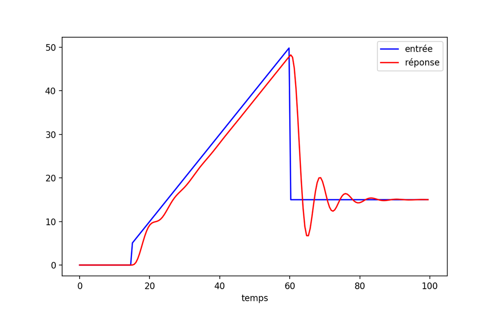

### Modes (pôles) dominants

Certaines fonctions de transfert peuvent contenir des pôles relativement éloignés les uns par rapport aux autres. Dans ces conditions, l'**approximation du transfert en ne retenant que les pôles dont la partie réelle est proche de l'origine** peut être justifiée.

**Illustration analytique**:le transfert $H(p)=\dfrac{1}{(1+\tau_1p)(1+\tau_2p)}$ a pour pôles $(-1/\tau_1,-1/\tau_2)$, et admet pour réponse indicielle (à faire):

\begin{eqnarray*} y(t)=1-\frac{\tau_1}{\tau_1-\tau_2}e^{-t/\tau_1}+\frac{\tau_2}{\tau_1-\tau_2} e^{-t/\tau_2} \end{eqnarray*}

Si $\tau_1 \gg \tau_2$ le second terme devient négligeable et la réponse avoisine celle d'un premier ordre $y(t)\approx 1-e^{-t/\tau_1}$

#### Remarque sur les zéros

Il est un peu plus compliqué à analyser

La décomposition en élements simples ne change pas les pôles, seuls leur coefficient

Des zéros à partie réelle positive peuvent donner des comportements non souhaités à l'origine (partir dans le mauvais sens au départ) (systèmes à non minimum de phase)

[output not shown]